# Peer review assignment Practical machine learning

The goal of your project is to predict the manner in which they did the exercise. This is the “classe” variable in the training set. You may use any of the other variables to predict with. You should create a report describing how you built your model, how you used cross validation, what you think the expected out of sample error is, and why you made the choices you did. You will also use your prediction model to predict 20 different test cases.

# Get the data

```r
knitr::opts_chunk$set(echo = TRUE)
setwd("Y:/Mijn Documenten/R-cursus/data/peer 8")
training <- read.csv(url("http://d396qusza40orc.cloudfront.net/predmachlearn/pml-training.csv"), na.strings=c("NA","#DIV/0!",""))
testing <- read.csv(url("http://d396qusza40orc.cloudfront.net/predmachlearn/pml-testing.csv"), na.strings=c("NA","#DIV/0!",""))
set.seed(42) #theanswer
```

# library packages

```r
library(caret)
library(randomForest)
```

```r
library(rpart)
library(rpart.plot)
library(RColorBrewer)
library(rattle)
library(ggplot2)
```

# exploratory analysis

```r
#dim(training); dim(testing); summary(training); summary(testing); str(training); str(testing); head(training); head(testing)
```

# Clean the data

```r
# Delete columns with only missing values
training<-training[,colSums(is.na(training)) == 0]
testing <-testing[,colSums(is.na(testing)) == 0]
# Delete irrelevant variables: user_name, raw_timestamp_part_1, raw_timestamp_part_,2 cvtd_timestamp, new_window, and  num_window (columns 1 to 7)
training   <-training[,-c(1:7)]
testing <-testing[,-c(1:7)]
```

## Devide the training set into two

with a 70/30 chance

```r
inTrain <- createDataPartition(y=training$classe, p=0.7, list=FALSE)
myTraining <- training[inTrain, ]; myTesting <- training[-inTrain, ]
#dim(myTraining); dim(myTesting)
```

# let’s have a look at classe

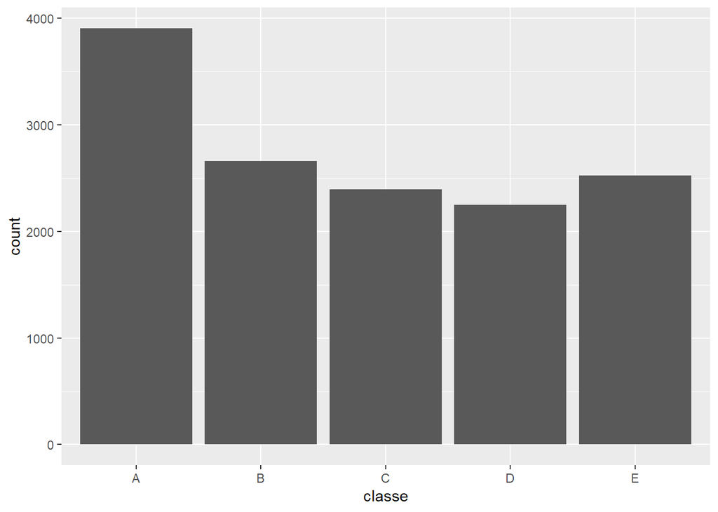

```r
ggplot(myTraining, aes(classe)) +
  geom_histogram(stat="count", position = "dodge")
```

In the plot we can see that the level A has the most counts and level D the least.

# Decision Tree

We fit a predictive model for activity recognition using Decision Tree algorithm.

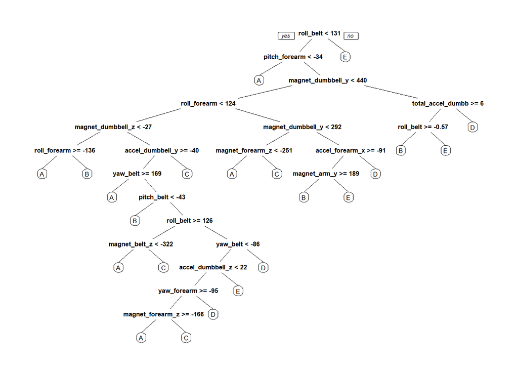

```r
model1 <- rpart(classe ~ ., data=myTraining, method="class")
prp(model1)
```

Now, we estimate the performance of the model on the testing data set.

```r
# Predicting dt:
predictiontree <- predict(model1, myTesting, type = "class")
confusionMatrix(myTesting$classe, predictiontree)
```

```
## Confusion Matrix and Statistics
##
##           Reference
## Prediction    A    B    C    D    E
##          A 1492   48   38   59   37
##          B  191  605  152   80  111
##          C   21   78  833   62   32
##          D   47   88  129  614   86
##          E   22   94  128   60  778
##
## Overall Statistics
##
##                Accuracy : 0.7344
##                  95% CI : (0.7229, 0.7457)
##     No Information Rate : 0.3013
##     P-Value [Acc > NIR] : < 2.2e-16
##
##                   Kappa : 0.6635
##  Mcnemar's Test P-Value : < 2.2e-16
##
## Statistics by Class:
##
##                      Class: A Class: B Class: C Class: D Class: E
## Sensitivity            0.8415   0.6627   0.6508   0.7017   0.7452
## Specificity            0.9557   0.8926   0.9581   0.9301   0.9372
## Pos Pred Value         0.8913   0.5312   0.8119   0.6369   0.7190
## Neg Pred Value         0.9333   0.9351   0.9080   0.9470   0.9446
## Prevalence             0.3013   0.1551   0.2175   0.1487   0.1774
## Detection Rate         0.2535   0.1028   0.1415   0.1043   0.1322
## Detection Prevalence   0.2845   0.1935   0.1743   0.1638   0.1839
## Balanced Accuracy      0.8986   0.7776   0.8044   0.8159   0.8412
```

```r
accuracy1 <- postResample(predictiontree, myTesting$classe)
ose1 <- 1 - as.numeric(confusionMatrix(myTesting$classe, predictiontree)$overall[1])
```

## Random forest prediction

Now we will fit a predictive model for classe using Random Forest algorithm. It automatically selects important variables and is robust to correlated covariates & outliers in general. We will use 5-fold cross validation when applying the algorithm.

```r
#fitting
Randomfrst <- train(classe ~ ., data = myTraining, method = "rf", trControl = trainControl(method = "cv", 5), ntree = 250)
Randomfrst
```

```
## Random Forest
##
## 13737 samples
##    52 predictor
##     5 classes: 'A', 'B', 'C', 'D', 'E'
##
## No pre-processing
## Resampling: Cross-Validated (5 fold)
## Summary of sample sizes: 10989, 10989, 10989, 10990, 10991
## Resampling results across tuning parameters:
##
##   mtry  Accuracy   Kappa
##    2    0.9909730  0.9885802
##   27    0.9898085  0.9871059
##   52    0.9807090  0.9755901
##
## Accuracy was used to select the optimal model using the largest value.
## The final value used for the model was mtry = 2.
```

Now, we estimate the performance of the model on the testing set.

```r
# Predicting rf:
predictRF <- predict(Randomfrst, myTesting)
confusionMatrix(myTesting$classe, predictRF)
```

```
## Confusion Matrix and Statistics
##
##           Reference
## Prediction    A    B    C    D    E
##          A 1673    1    0    0    0
##          B    8 1131    0    0    0
##          C    0    9 1015    2    0
##          D    0    0   18  946    0
##          E    0    0    0    1 1081
##
## Overall Statistics
##
##                Accuracy : 0.9934
##                  95% CI : (0.991, 0.9953)
##     No Information Rate : 0.2856
##     P-Value [Acc > NIR] : < 2.2e-16
##
##                   Kappa : 0.9916
##  Mcnemar's Test P-Value : NA
##
## Statistics by Class:
##
##                      Class: A Class: B Class: C Class: D Class: E
## Sensitivity            0.9952   0.9912   0.9826   0.9968   1.0000
## Specificity            0.9998   0.9983   0.9977   0.9964   0.9998
## Pos Pred Value         0.9994   0.9930   0.9893   0.9813   0.9991
## Neg Pred Value         0.9981   0.9979   0.9963   0.9994   1.0000
## Prevalence             0.2856   0.1939   0.1755   0.1613   0.1837
## Detection Rate         0.2843   0.1922   0.1725   0.1607   0.1837
## Detection Prevalence   0.2845   0.1935   0.1743   0.1638   0.1839
## Balanced Accuracy      0.9975   0.9948   0.9902   0.9966   0.9999
```

```r
accuracy2 <- postResample(predictRF, myTesting$classe)
ose2 <- 1 - as.numeric(confusionMatrix(myTesting$classe, predictRF)$overall[1])
```

# Predicting the testing data set

```r
predict(Randomfrst, testing[, -length(names(testing))])
```

```
##  [1] B A B A A E D B A A B C B A E E A B B B
## Levels: A B C D E
```

This shows the predicted outcomes based on our fitted random forest model. With an accuracy above 99% on our cross-validation data, we can expect that very few, or none, of the test samples will be missclassified.